# Исследование связей между режиссерами и актерами

### Подготовка данных:

Для начала я решил немного видоизменить данные чтобы сделать будущую сеть более доступной для понимания. С помощью пакета dplyr я соединил два датафрейма в один, а данные о принадлежности определенного человека к его профессии поместил в столбец с именами, добавив приписку из “cast” или “director”.

По итогу я визуализировал сеть, чтобы увидеть базовый результат, пока без выявления каких-либо тенденций.

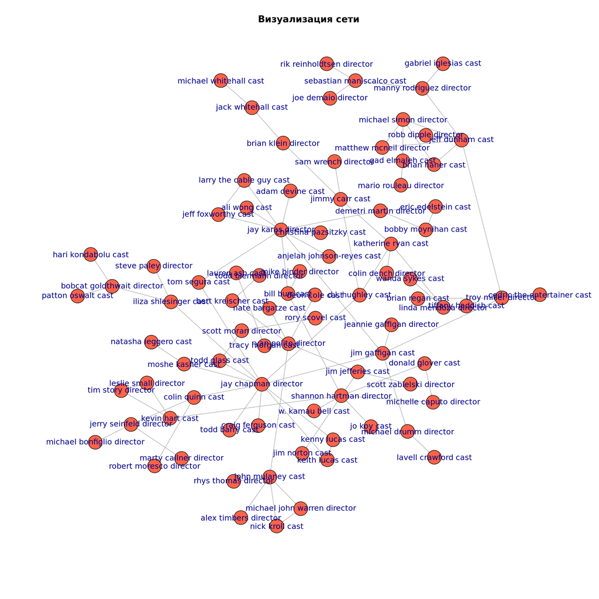

### Исследовательские вопросы:

Для исследования я поставил следующие вопросы:

1. Какие режиссеры наиболее востребованны? (Рекомендация фильмов на основе востребованности режиссеров)
2. Какие актеры связанны с наиболее востребованными режиссерами? (Рекомендация фильмов на основе любимых актеров пользователя, снимавшихся в фильмах востребованных режиссеров)

### Определение мер центральности:

Теперь стоит найти центральности вершин. Я выбрал методы “degree” и “betwenness”

Наибольшее количество связей в сети у режиссеров Jay Chapman, Jay Karas и Shannon Hartman, по полученному результату можно судить о наибольшей востребованности данных режиссеров, т.к большее количество связей соответствует большему количеству фильмов и совместных проектов с актерами.

### Выявление соообществ:

Я решил выявить сообщества по битвинности, т.к мой второй исследовательский вопрос заключается в том, какие актеры связаны с наиболее востребованными режиссерами. С помощью выявления сообществ по показателям битвинности можно будет посмотреть, какие актеры из наиболее успешных (имеющих не одну связь) связаны с востребвоанными режиссерами.

Мне кажется, что данный метод наиболее подходит в силу того, что degree отражает простое количество связей, а значит это может быть и односторонняя связь актера с режиссером. Я считаю, что этого мало для однозначной рекомендации, ибо участие в одном проекте не самый лучший показатель как для актера, так и для режиссера.

### Визуализация результатов:

Такими вышли визуализации для исследвоания поставленных мною вопросов.

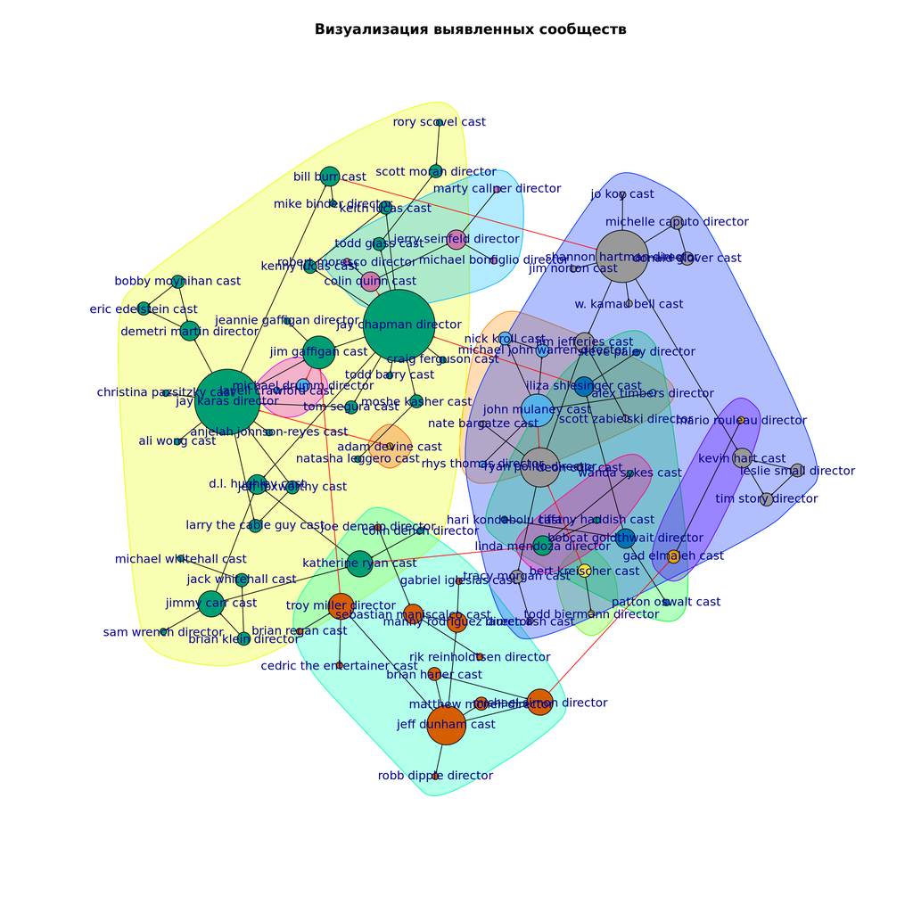

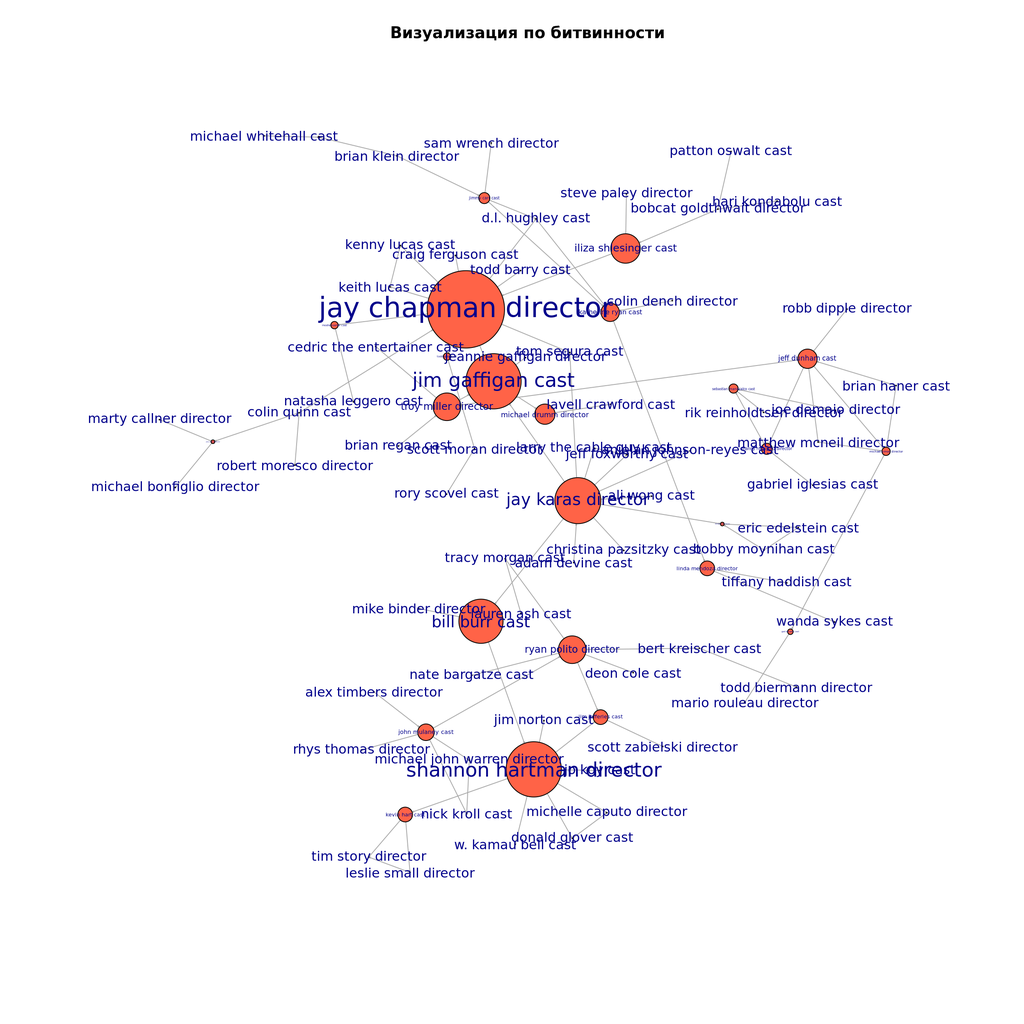

### Интерпретация результатов и ответы на исследовательские вопросы:

1. На полученных сетях можно увидеть, что такие режиссеры как Jay Chapman, Jay Karas, Shannon Hartman наиболее востребованны, т.к имеют больше связей с остальными участниками списка. Отталкиваясь от исследвоательского вопроса, можно предложить систему рекоммендаций фильмов на основе востребованности режиссеров, так, пользователю не имеещему достаточной истории просмотра фильмов для формирования персональных рекоммендаций можно посоветовать фильмы востребованных режиссеров, перечисленных выше. После чего, выбрав первичный набор можно будет формировать более персонализированный список рекоммендаций для пользователя.
2. Кроме того, если пользователь уже имеет любимых актеров, возможно предложить систему рекоммендаций, которую я предлагаю в итоге получения ответа на свой второй исследовательский вопрос. Так, можно пользователю предложить фильмы востребвоанных режиссеров, в которых есть какой-либо из его любимых актеров. Такими актерами оказались Bill Burr, Jim Gaffigan, Iliza Shlesinger, Donald Glover, Keith Lucas, Moshe Kasher, Kevin Hart. Если же его любимый актер не снимался в фильмах самых востребованных режиссеров, можно предлaгать менее востребованных по убыванию, связанных с его любимым актером.

#### Дополнительные данные:

1. Я бы привлек данные о средней оценке фильмов, в которых снимался тот или иной актер, либо средние оценки фильмов режиссеров. Подобные данные смогли бы помочь решить проблему с востребованными, но не очень хорошими актерами, которые получают множество связей из-за низкой стоимости своей работы.
2. Еще я бы использовал данные о жанрах фильмов, чтобы можно было сделать рекоммендательную систему для пользвоателя, не знающего имена конкретных режиссеров или актеров, но понимающего свои предпочтения в жанрах. Так, на основе связей режиссеровс жанрами, можно было бы рекоммендовать фильмы с режиссерами, которые снимаютсяв определенном любимом жане пользователя.